# Time Series: A First Course with Bootstrap Starter

# Lesson 10-8: Model Assessment

- Once we have fitted a model, we need to assess the fit.
- We should also compare to competing models.

## Remark 10.8.1. Computing Residuals

- If an ARMA model was fitted using the Gaussian divergence, we get the one-step-ahead forecast errors (in-sample) as output of the Durbin-Levinson algorithm. These are *time series residuals*.
- If our model is a good fit, the time series residuals should resemble white noise.

## Example 10.8.2. Residuals of MA(1) Model Fitted to Non-Defense Capitalization

- We continue Exercise 10.47 of previous lesson. First load all the needed functions.

```r
polymul <- function(a,b)
{
    bb <- c(b,rep(0,length(a)-1))
    B <- toeplitz(bb)
    B[lower.tri(B)] <- 0
    aa <- rev(c(a,rep(0,length(b)-1)))
    prod <- B %*% matrix(aa,length(aa),1)
    return(rev(prod[,1]))
}

ARMAauto <- function(phi,theta,maxlag)
{
    p <- length(phi)
    q <- length(theta)
    gamMA <- polymul(c(1,theta),rev(c(1,theta)))
    gamMA <- gamMA[(q+1):(2*q+1)]
    if (p > 0)
    {
        Amat <- matrix(0,nrow=(p+1),ncol=(2*p+1))
        for(i in 1:(p+1))
        {
            Amat[i,i:(i+p)] <- c(-1*rev(phi),1)
        }
        Amat <- cbind(Amat[,(p+1)],as.matrix(Amat[,(p+2):(2*p+1)]) +
            t(matrix(apply(t(matrix(Amat[,1:p],p+1,p)),2,rev),p,p+1)))
        Bmat <- matrix(0,nrow=(q+1),ncol=(p+q+1))
        for(i in 1:(q+1))
        {
            Bmat[i,i:(i+p)] <- c(-1*rev(phi),1)
        }
        Bmat <- t(matrix(apply(t(Bmat),2,rev),p+q+1,q+1))
        Bmat <- matrix(apply(Bmat,2,rev),q+1,p+q+1)
        Bmat <- Bmat[,1:(q+1)]
        Binv <- solve(Bmat)
        gamMix <- Binv %*% gamMA
        if (p <= q) { gamMix <- matrix(gamMix[1:(p+1),],p+1,1)
            } else gamMix <- matrix(c(gamMix,rep(0,(p-q))),p+1,1)
        gamARMA <- solve(Amat) %*% gamMix
    } else gamARMA <- gamMA[1]

    gamMA <- as.vector(gamMA)
    if (maxlag <= q) gamMA <- gamMA[1:(maxlag+1)] else gamMA <- c(gamMA,rep(0,(maxlag-q)))
    gamARMA <- as.vector(gamARMA)
    if (maxlag <= p) gamARMA <- gamARMA[1:(maxlag+1)] else {
    for(k in 1:(maxlag-p))
    {
        len <- length(gamARMA)
        acf <- gamMA[p+1+k]
        if (p > 0) acf <- acf + sum(phi*rev(gamARMA[(len-p+1):len]))
        gamARMA <- c(gamARMA,acf)
    } }
    return(gamARMA)
}

dl.alg <- function(gamma,data)
{
    # assumes that n > 1
    # assumes gamma includs lags 0 through n
    n <- length(data)
    kappa.vec <- gamma[2]/gamma[1]
    varphi.vec <- kappa.vec
    quad.new <- 0
    quads <- NULL
    ldet <- 0
    ldets <- NULL
    eps <- NULL

    for(k in 2:n)
    {
        schur.new <- gamma[1] - t(varphi.vec) %*% rev(gamma[2:k])
        eps.new <- data[k] - t(varphi.vec) %*% data[1:(k-1)]
        eps <- c(eps,eps.new)
        quad.new <- quad.new + eps.new^2/schur.new
        quads <- c(quads,quad.new)
        ldet <- ldet + log(schur.new)
        ldets <- c(ldets,ldet)
        kappa.new <- (gamma[k+1] - sum(varphi.vec*gamma[2:k]))/schur.new
        kappa.new <- kappa.new[1,1]
        if(abs(kappa.new) < 10^(-15)) kappa.new <- 0
        kappa.vec <- c(kappa.vec,kappa.new)
        varphi.vec <- rev(varphi.vec) - kappa.new * varphi.vec
        varphi.vec <- rev(c(varphi.vec,kappa.new))
    }
    gauss.lik <- n*log(2*pi) + quads[n-1] + ldets[n-1]
    gauss.likprof <- n*(1 + log(2*pi)) + n*log(quads[n-1]/n) + ldets[n-1]

    return(list(gauss.lik,gauss.likprof,quads[n-1]/n,eps))
}

psi2phi <- function(psi)
{
    p <- length(psi)
    pacfs <- (exp(psi)-1)/(exp(psi)+1)
    if(p==1)
    {
        phi <- pacfs
    } else
    {
        phi <- as.vector(pacfs[1])
        for(j in 2:p)
        {
            A.mat <- diag(j-1) - pacfs[j]*diag(j-1)[,(j-1):1,drop=FALSE]
            phi <- A.mat %*% phi
            phi <- c(phi,pacfs[j])
        }
    }
    return(phi)
}

phi2psi <- function(phi)
{
    p <- length(phi)
    pacfs <- phi[p]
    if(p > 1)
    {
        phi <- as.vector(phi[-p])
        for(j in p:2)
        {
            A.mat <- diag(j-1) - pacfs[1]*diag(j-1)[,(j-1):1,drop=FALSE]
            phi <- solve(A.mat,phi)
            pacfs <- c(phi[j-1],pacfs)
            phi <- phi[-(j-1)]
        }
    }
    psi <- log(1+pacfs) - log(1-pacfs)
    return(psi)
}
```

- We use a profile likelihood for an ARMA process.

```r
likprof.arma <- function(psi,q,data)
{
    n <- length(data)
    r <- length(psi)
    p <- r-q
    phi <- NULL
    theta <- NULL
    if(p > 0) { phi <- psi2phi(psi[1:p]) }
    if(q > 0) { theta <- -1*psi2phi(psi[(p+1):(p+q)]) }
    gamma <- ARMAauto(phi,theta,n)
    lik <- dl.alg(gamma,data)[[2]]
    return(lik)
}
```

- We can fit the series as before.

```r
ndc <- read.table("Nondefcap.dat")
ndc <- ts(ndc[,2],start=c(1992,3),frequency=12,names= "NewOrders")
ndc.diff <- diff(ndc)
n <- length(ndc.diff)
psi.init <- 0
fit.ma1 <- optim(psi.init,likprof.arma,q=1,data=ndc.diff,method="BFGS")
psi.mle <- fit.ma1$par
theta.mle <- -1*psi2phi(psi.mle)
gamma <- ARMAauto(NULL,theta.mle,n)
sig2.mle <- dl.alg(gamma,ndc.diff)[[3]]
```

- So the parameter estimates are $\widehat{\theta_1} =$ -0.4911631 and $\widehat{\sigma^2} =$ 0.0051809.
- We can get the residuals as output as well.

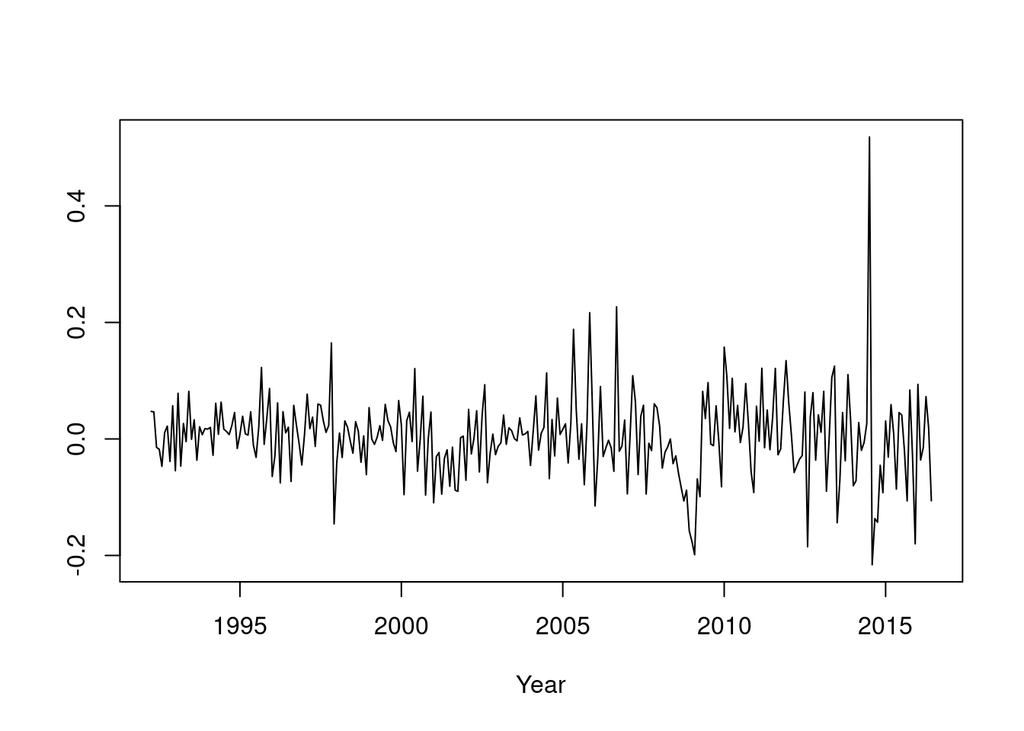

```r
resid.mle <- dl.alg(gamma,ndc.diff)[[4]]
plot(ts(resid.mle,start=c(1992,4),frequency=12),
     xlab="Year",ylab="",lwd=1)
```

- Some structure in the residuals is evident around 2008 (the nadir of the Great Recession).
- We can examine the serial correlation structure using the sample acf (and pacf):

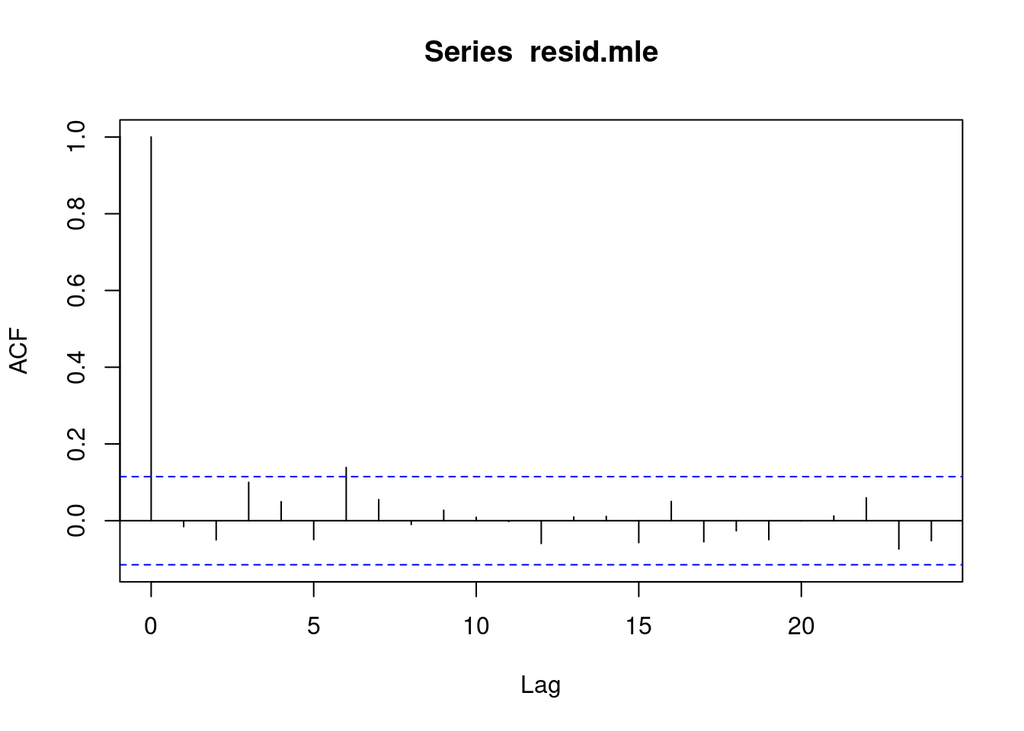

```r
acf(resid.mle)
```

## Remark 10.8.6. Portmanteau Statistics

- To assess whether the residuals resemble white noise, we can measure the autocovariances.
- We can combine into a single measure by taking a sum of squared autocorrelations.
- This is an aggregate measure, like a *portmanteau* (suitcase) of statistics.

## Definition 10.8.7.

- The *total variation* of a stationary time series with absolutely summable acvf is
  $$\zeta = \sum_{k \neq 0} { \gamma (k) }^2.$$
- Note that $\zeta = 0$ if and only if the process is white noise.

## Example 10.8.10. Total Variation White Noise Testing of Non-Defense Capitalization

- We apply the total variation test statistic to the time series residuals from the fit of an MA(1) to Non-Defense Capitalization.

```r
n <- length(resid.mle)
gamma.hat <- acf(resid.mle,lag.max=n,plot=FALSE,type="covariance")$acf
lambda <- seq(-n/2+1,n/2)*2*pi/n
pgram <- cos(0*lambda)*gamma.hat[1]
for(h in 1:(n-1))
{
    pgram <- pgram + 2*cos(h*lambda)*gamma.hat[h+1]
}
pgram <- ts(pgram,start=0,frequency=n)
tot.var <- .5*mean(pgram^2) - gamma.hat[1]^2
tstat <- sqrt(n)*tot.var/sqrt(2*gamma.hat[1]^4)
pval <- 1-pnorm(tstat)
```